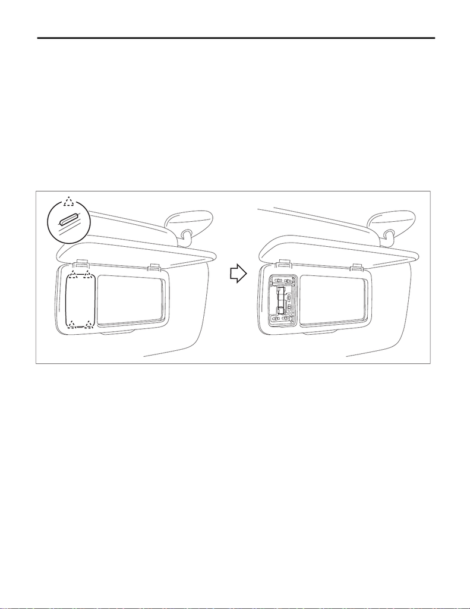

Vanity Mirror Light

LIGHTING SYSTEM

36.Vanity Mirror Light

A: REMOVAL

NOTE:

The vanity mirror light is integrated into the sun visor assembly. Replace the sun visor assembly if faulty.

<Ref. to EI-97, REMOVAL, Sun Visor.>

1) Disconnect the ground cable from battery. <Ref. to NT-5, BATTERY, NOTE, Note.>

NOTE:

For models other than STI model, disconnect the ground terminal from battery sensor.

2) Release the claws and remove the lens and vanity mirror light bulb.

CAUTION:

• Use a dry clean cloth so that no grease or water adheres to the glass portion of the bulb.

age.

B: INSTALLATION

1) Install the vanity mirror light bulb and lens.

CAUTION:

Use a dry clean cloth so that no grease or water adheres to the glass portion of the bulb.

2) Connect the battery ground terminal. <Ref. to NT-5, BATTERY, NOTE, Note.>

NOTE:

For models other than STI model, connect the ground terminal to battery sensor.